# Additional Coding: Update #4

davegoblue

September 26, 2016

## Overview

This document explores video poker hands, using http://wizardofodds.com/games/video-poker/methodology/ as a template, and applying DataCamp_Insights_v001 materials where applicable. This document builds on the more salient components of the analysis in AdditionalCoding_v003.Rmd.

## Analysis Approach

The Wizard of Odds suggests an 11-step approach to calculating the returns for a video poker pay table:

1. Initialize arrays for discarding 0-5 cards
2. Loop through all 52c5 hands, score them based on their poker value, then place them in the appropriate arrays (each of discard 0 through discard 5)
3. Create the 134,459 non-duplicate starting hands possible (e.g., Ad Kh Tc 9c 3d is the same as As Kh Td 9d 3s), and assign it a weighting based on how much duplication it covers
4. Lookup each of the 134,459 hands and score the discard 0 (hold 5) option
5. Lookup every possible discard 1 (hold 4) option, find the EV in the discard 1 array and then subtract the outcome in the discard 0 array (cannot get back the same hand)
6. Lookup every possible discard 2 (hold 3) option, find the EV in the discard 2 array and then subtract the outcomes in the discard 1 array and then add back the outcome in the discard 0 array (double-subtracted)
7. Lookup every possible discard 3 (hold 2) option, find the EV in the discard 3 array and then subtract the outcomes in the discard 2 array and then add back the outcomes in the discard 1 array and then subtract out the outcome in the discard 0 array (typical set theory add/subtract)
8. Lookup every possible discard 4 (hold 1) option, find the EV in the discard 4 array and then subtract the outcomes in the discard 3 array and then add back the outcomes in the discard 2 array and then subtract out the outcome in the discard 1 array and then add back the outcome in the discard 0 array (typical set theory add/subtract)
9. Lookup every possible discard 5 (hold 0) option, find the EV in the discard 5 array and then subtract the outcomes in the discard 4 array and then add back the outcomes in the discard 3 array and then subtract out the outcome in the discard 2 array and then add back the outcome in the discard 1 array and then subtract out the outcome of the discard 0 array (typical set theory add/subtract)
10. Calculate the EV of every possible decision, and assign the appropriate weightings
11. Determine overall return, or other statistics of interest about the game

### Step 1: Initialize Arrays

```r
library(tidyr)
library(dplyr)
```

```r
library(ggplot2)


startTime <- proc.time()


# Declare overall game variables
nScores <- 10  # Standard JB Outcomes
scoreVector <- c(-1L,  0L,  1L,  2L,   3L,
                  5L,  8L, 24L, 49L, 799L
                 )  # Standard JB outcomes, sorted low to high


# Create the relevant arrays
array0 <- matrix(data=0L, nrow=choose(52, 5), ncol=nScores)
array1 <- matrix(data=0L, nrow=choose(52, 4), ncol=nScores)
array2 <- matrix(data=0L, nrow=choose(52, 3), ncol=nScores)
array3 <- matrix(data=0L, nrow=choose(52, 2), ncol=nScores)
array4 <- matrix(data=0L, nrow=choose(52, 1), ncol=nScores)
array5 <- matrix(data=0L, nrow=choose(52, 0), ncol=nScores)


proc.time() - startTime
```

```
##    user  system elapsed
##    0.30    0.03    0.36
```

### Step 2: Create/Score Hands, Create Indexing, and Place Scores in Appropriate Arrays

#### Step 2a: Create/Score Hands

First, the 52c5 possible hands are created and scored. For this coding, the standard 9-6 Jacks or Better pay table is used, subtracting off the coin that was bet (e.g., “win 1” is really a break-even):

```r
startTime <- proc.time()


# Create the 52c5 hands
aHands <- t(combn(1:52, 5))
str(aHands)
```

```
##  int [1:2598960, 1:5] 1 1 1 1 1 1 1 1 1 1 ...
```

```r
proc.time() - startTime
```

```
##    user  system elapsed
##    2.63    0.02    2.68
```

```r
# Find the ranks and suits
aRanks <- 1 + (aHands-1) %% 13
aSuits <- (aHands-1) %/% 13


# Find the flushes
aFlush <- aSuits[, 1] == aSuits[, 5]


# Find the straights
strMatrix <- matrix(data=0L, nrow=13, ncol=10)
strMatrix[c(1, 10, 11, 12, 13), 1] <- 1L
for (intCtr in 1:9) { strMatrix[intCtr:(intCtr+4), intCtr+1] <- 1L }

aRankCount <- matrix(data=-1L, nrow=choose(52, 5), ncol=13)
for (intCtr in 1:13) { aRankCount[, intCtr] <- rowSums(aRanks == intCtr) }


# Find max and count of ranks (sufficient to determine quds, full houses, trips, two pair, and pair)
aQuads <- rowSums(aRankCount == 4)
aTrips <- rowSums(aRankCount == 3)
aPairs <- rowSums(aRankCount == 2)
aHiPair <- rowSums(aRankCount[, c(1, 11, 12, 13)] == 2)
aStraight <- rowSums( ((aRankCount == 1) %*% strMatrix) == 5)

aType <- rep(-1L, choose(52, 5))


# Declare types
aType[aFlush == 1 & aStraight == 1 & aRankCount[, 1] == 1 &
          aRankCount[, 13] == 1] <- 799  # Royal Flush
aType[aFlush == 1 & aStraight == 1 &
          (aRankCount[, 1] == 0 | aRankCount[, 13] == 0)] <- 49  # Straight Flush
aType[aQuads == 1] <- 24  # Quads
aType[aTrips == 1 & aPairs == 1] <- 8  # Full House
aType[aFlush == 1 & aStraight == 0] <- 5  # Flush
aType[aFlush == 0 & aStraight == 1] <- 3  # Straight
aType[aTrips == 1 & aPairs == 0] <- 2  # Trips
aType[aPairs == 2] <- 1  # Two Pair
aType[aTrips == 0 & aPairs == 1 & aHiPair == 1] <- 0  # High Pair


proc.time() - startTime
```

```
##    user  system elapsed
##    9.33    1.10   10.64
```

The process takes ~10 seconds, but with the many interim files, it also consumes ~1.5 GB.

#### Step 2b: Create Indexing

Next, a methodology is created to index any combination of held cards:

```r
startTime <- proc.time()


# Create a matrix to hold results for choose(n, k)
mtxCombin <- matrix(data=0L, nrow=52, ncol=5)
for (intCtr in 1:52) {
    for (intCtr2 in 1:5) {
        # Note that choose() is a guarded function where choose(n, k) returns 0 for k > n
        mtxCombin[intCtr, intCtr2] <- choose(intCtr, intCtr2)
    }
}


idxCard1 <- function(c1) {
    # Just return yourself
    c1
}

idxCard2 <- function(c1, c2) {
    # Need to convert the C++ algorithm which is 0:51 to R which wants 1:52
    1 + mtxCombin[52, 2] - mtxCombin[53-c1, 2] +
        mtxCombin[52-c1, 1] - mtxCombin[53-c2, 1]
}

idxCard3 <- function(c1, c2, c3) {
    # Need to convert the C++ algorithm which is 0:51 to R which wants 1:52
    1 + mtxCombin[52, 3] - mtxCombin[53-c1, 3] +
        mtxCombin[52-c1, 2] - mtxCombin[53-c2, 2] +
        mtxCombin[52-c2, 1] - mtxCombin[53-c3, 1]
}

idxCard4 <- function(c1, c2, c3, c4) {
    # Need to convert the C++ algorithm which is 0:51 to R which wants 1:52
    1 + mtxCombin[52, 4] - mtxCombin[53-c1, 4] +
        mtxCombin[52-c1, 3] - mtxCombin[53-c2, 3] +
        mtxCombin[52-c2, 2] - mtxCombin[53-c3, 2] +
        mtxCombin[52-c3, 1] - mtxCombin[53-c4, 1]
}

idxCard5 <- function(c1, c2, c3, c4, c5) {
    # Need to convert the C++ algorithm which is 0:51 to R which wants 1:52
    1 + mtxCombin[52, 5] - mtxCombin[53-c1, 5] +
        mtxCombin[52-c1, 4] - mtxCombin[53-c2, 4] +
        mtxCombin[52-c2, 3] - mtxCombin[53-c3, 3] +
        mtxCombin[52-c3, 2] - mtxCombin[53-c4, 2] +
        mtxCombin[52-c4, 1] - mtxCombin[53-c5, 1]
}

proc.time() - startTime
```

```
##    user  system elapsed
##    0.02    0.00    0.01
```

This allows any combination of 1-5 cards to be converted to a relevant index. This will be useful for several further components of the program.

#### Step 2c: Place Scores in Appropriate Arrays

```r
startTime <- proc.time()


# Create array5, which is discarding everything
b <- data.frame(idx=1, val=match(aType, scoreVector)) %>%
    group_by(idx, val) %>%
    summarize(ct=n()) %>%
    spread(val, ct, fill=0)

all.equal( as.integer(colnames(b[, -1])) , 1:nScores )
```

```
## [1] TRUE
```

```r
nrow(b) == nrow(array5)
```

```
## [1] TRUE
```

```r
array5 <- t(as.matrix(as.integer(b[, -1])))


proc.time() - startTime
```

```
##    user  system elapsed
##    0.24    0.09    0.35
```

```r
# Create array4, which is discarding four and keeping one
idx <- integer(0)
for (intCtr in 1:5) { idx <- c(idx, idxCard1(c1=aHands[, intCtr])) }
b <- data.frame(idx=idx, val=rep(match(aType, scoreVector), 5)) %>%
    group_by(idx, val) %>%
    summarize(ct=n()) %>%
    spread(val, ct, fill=0)

all.equal( unique(as.integer(colnames(b[, -1]))) , 1:nScores )
```

```
## [1] TRUE
```

```r
nrow(b) == nrow(array4)
```

```
## [1] TRUE
```

```r
array4 <- as.matrix(b[, -1])


proc.time() - startTime
```

```
##    user  system elapsed
##    1.27    0.18    1.48
```

```r
# Create array3, which is discarding three and keeping two
idx <- integer(0)
for (intCtr in 1:4) {
    for (intCtr2 in (intCtr+1):5) {
        idx <- c(idx, idxCard2(c1=aHands[, intCtr], c2=aHands[, intCtr2]))
    }
}
b <- data.frame(idx=idx, val=rep(match(aType, scoreVector), 10)) %>%
    group_by(idx, val) %>%
    summarize(ct=n()) %>%
    spread(val, ct, fill=0)

all.equal( unique(as.integer(colnames(b[, -1]))) , 1:nScores )
```

```
## [1] TRUE
```

```r
nrow(b) == nrow(array3)
```

```
## [1] TRUE
```

```r
array3 <- as.matrix(b[, -1])


proc.time() - startTime
```

```
##    user  system elapsed
##    5.17    0.92    6.11
```

```r
# Create array2, which is discarding two and keeping three
idx <- integer(0)
for (intCtr in 1:3) {
    for (intCtr2 in (intCtr+1):4) {
        for (intCtr3 in (intCtr2+1):5) {
            idx <- c(idx, idxCard3(c1=aHands[, intCtr], c2=aHands[, intCtr2],
                                   c3=aHands[, intCtr3]
                                   )
                     )
        }
    }
}
b <- data.frame(idx=idx, val=rep(match(aType, scoreVector), 10)) %>%
    group_by(idx, val) %>%
    summarize(ct=n()) %>%
    spread(val, ct, fill=0)

all.equal( unique(as.integer(colnames(b[, -1]))) , 1:nScores )
```

```
## [1] TRUE
```

```r
nrow(b) == nrow(array2)
```

```
## [1] TRUE
```

```r
array2 <- as.matrix(b[, -1])


proc.time() - startTime
```

```
##    user  system elapsed
##   11.16    1.71   12.93
```

```r
# Create array1, which is discarding one and keeping four
idx <- integer(0)
for (intCtr in 1:2) {
    for (intCtr2 in (intCtr+1):3) {
        for (intCtr3 in (intCtr2+1):4) {
            for (intCtr4 in (intCtr3+1):5) {
                idx <- c(idx, idxCard4(c1=aHands[, intCtr], c2=aHands[, intCtr2],
                                       c3=aHands[, intCtr3], c4=aHands[, intCtr4]
                                       )
                         )
            }
        }
    }
}
b <- data.frame(idx=idx, val=rep(match(aType, scoreVector), 5)) %>%
    group_by(idx, val) %>%
    summarize(ct=n()) %>%
    spread(val, ct, fill=0)

all.equal( unique(as.integer(colnames(b[, -1]))) , 1:nScores )
```

```
## [1] TRUE
```

```r
nrow(b) == nrow(array1)
```

```
## [1] TRUE
```

```r
array1 <- as.matrix(b[, -1])


proc.time() - startTime
```

```
##    user  system elapsed
##   18.54    2.31   20.93
```

```r
# Create array0, which is discarding zero and keeping five
# Can use indices 1:choose(52, 5)
idx <- 1:choose(52, 5)

b <- data.frame(idx=idx, val=rep(match(aType, scoreVector), 1), ct=1) %>%
    spread(val, ct, fill=0)

all.equal( unique(as.integer(colnames(b[, -1]))) , 1:nScores )
```

```
## [1] TRUE
```

```r
nrow(b) == nrow(array0)
```

```
## [1] TRUE
```

```r
array0 <- as.matrix(b[, -1])


proc.time() - startTime
```

```
##    user  system elapsed
##   26.90    2.95   29.95
```

Next, each of the arrays is double-checked for proper row sums, then converted to an expected value:

```r
startTime <- proc.time()


foo <- function(x, y) { z <- rowSums(x); c(mean(z), choose(47+y, y), length(z), max(z) == min(z)) }
foo(array0, 0)
```

```
## [1]       1       1 2598960       1
```

```r
foo(array1, 1)
```

```
## [1]     48     48 270725      1
```

```r
foo(array2, 2)
```

```
## [1]  1176  1176 22100     1
```

```r
foo(array3, 3)
```

```
## [1] 19600 19600  1326     1
```

```r
foo(array4, 4)
```

```
## [1] 249900 249900     52      1
```

```r
foo(array5, 5)
```

```
## [1] 2598960 2598960       1       1
```

```r
ev0 <- array0 %*% as.matrix(scoreVector)
ev1 <- array1 %*% as.matrix(scoreVector) / choose(48, 1)
ev2 <- array2 %*% as.matrix(scoreVector) / choose(49, 2)
ev3 <- array3 %*% as.matrix(scoreVector) / choose(50, 3)
ev4 <- array4 %*% as.matrix(scoreVector) / choose(51, 4)
ev5 <- array5 %*% as.matrix(scoreVector) / choose(52, 5)

summary(ev0)
```

```
##        V1
##  Min.   : -1.0000
##  1st Qu.: -1.0000
##  Median : -1.0000
##  Mean   : -0.6631
##  3rd Qu.: -1.0000
##  Max.   :799.0000
```

```r
summary(ev1)
```

```
##        V1
##  Min.   :-1.0000
##  1st Qu.:-0.9375
##  Median :-0.8750
##  Mean   :-0.6631
##  3rd Qu.:-0.6250
##  Max.   :24.0000
```

```r
summary(ev2)
```

```
##        V1
##  Min.   :-0.9107
##  1st Qu.:-0.8138
##  Median :-0.8138
##  Mean   :-0.6631
##  3rd Qu.:-0.6624
##  Max.   : 3.2653
```

```r
summary(ev3)
```

```
##        V1
##  Min.   :-0.8122
##  1st Qu.:-0.7731
##  Median :-0.6898
##  Mean   :-0.6631
##  3rd Qu.:-0.6506
##  Max.   : 0.5143
```

```r
summary(ev4)
```

```
##        V1
##  Min.   :-0.7177
##  1st Qu.:-0.7049
##  Median :-0.7049
##  Mean   :-0.6631
##  3rd Qu.:-0.5668
##  Max.   :-0.5582
```

```r
summary(ev5)
```

```
##        V1
##  Min.   :-0.6631
##  1st Qu.:-0.6631
##  Median :-0.6631
##  Mean   :-0.6631
##  3rd Qu.:-0.6631
##  Max.   :-0.6631
```

```r
proc.time() - startTime
```

```
##    user  system elapsed
##    0.48    0.11    0.60
```

Encouragingly, the mean EV is the same everywhere. The max/min gain variance as the number of cards kept increases, meaning there is opportunity to raise the overall EV by picking the best hold of 0-5 cards.

### Step 3: Create/Weight non-duplicate hands

The next step is to create the 134,459 non-duplicate starting hands possible (e.g., Ad Kh Tc 9c 3d is the same as As Kh Td 9d 3s), and assign each a weighting based on how much duplication it covers.

This is adapted heavily from clever thinking at http://wizardofodds.com/games/video-poker/methodology/, using in order:

- Four of a Kind (all that matters is what is the rank of the quad/kicker)
- Full House (need to know ranks for A full of B, as well as whether B contains the fourth suit or not)
- Trips (singletons can be all of fourth suit, one match and one fourth suit, no fourth suit/same, or no fourth suit/different)
- Two Pair (suits matter for how much is in common between the two pairs, as well as the singleton)
- Pair (many combinations for suits of the singletons)
- Nothing (suits matter a great deal!)

```r
startTime <- proc.time()


# Quads are simple - there are 13 possible quads and 12 possible kickers
# Each hand can be captured once with a weight of 4 since the kicker will always match one suit
quadSmall <- matrix(data=0L, nrow=13*12, ncol=5)
quadWeight <- rep(4L, times=13*12)
curIdx <- 1

for (intCtr in 1:13) {
    for (intCtr2 in (1:13)[-intCtr]) {
        quadSmall[curIdx, ] <- sort(c(intCtr, intCtr+13, intCtr+26, intCtr+39, intCtr2))
        curIdx <- curIdx + 1
    }
}


# Full Houses are not too much more complex, though there are two suit pairing options for each
fhSmall <- matrix(data=0L, nrow=13*12*2, ncol=5)
fhWeight <- rep(12L, times=13*12*2)
curIdx <- 1

for (intCtr in 1:13) {
    for (intCtr2 in (1:13)[-intCtr]) {
        # First option has both pairs matching the suits of the trips
        fhSmall[curIdx, ] <- sort(c(intCtr, intCtr+13, intCtr+26, intCtr2, intCtr2+13))
        # Second option has one pair not matching the suits of the trips
        fhSmall[curIdx+1, ] <- sort(c(intCtr, intCtr+13, intCtr+26, intCtr2, intCtr2+39))
        curIdx <- curIdx + 2
    }
}


# Trips become a touch more complicated
# There is weight 24 for both singletons match different trips suits
# There is weight 12 for one singleton matches and the other does not
# There is weight 12 for both singletons match the same trips suit
# There is weight 4 for both singletons match each other but not any of the trips suits
tripSmall <- matrix(data=0L, nrow=13*choose(12, 2)*5, ncol=5)
tripWeight <- rep(c(24, 12, 12, 12, 4), times=13*choose(12,2))
curIdx <- 1

for (intCtr in 1:13) {
    intAvail <- (1:13)[-intCtr]
    for (intCtr2 in intAvail[-length(intAvail)]) {
        for (intCtr3 in intAvail[intAvail > intCtr2]) {
            # First option has both singletons matching a different trips suit
            tripSmall[curIdx, ] <- sort(c(intCtr, intCtr+13, intCtr+26, intCtr2, intCtr3+13))
            # Second option has singleton one matching a trips suit and singleton two not
            tripSmall[curIdx+1, ] <- sort(c(intCtr, intCtr+13, intCtr+26, intCtr2, intCtr3+39))
            # Third option has singleton two matching a trips suit and singleton one not
            tripSmall[curIdx+2, ] <- sort(c(intCtr, intCtr+13, intCtr+26, intCtr2+39, intCtr3))
            # Fourth option has both singletons matching the same trips suit
            tripSmall[curIdx+3, ] <- sort(c(intCtr, intCtr+13, intCtr+26, intCtr2, intCtr3))
            # Fifth option has both singletons failing to match a trips suit
            tripSmall[curIdx+4, ] <- sort(c(intCtr, intCtr+13, intCtr+26, intCtr2+39, intCtr3+39))
            # Increment the index by 5
            curIdx <- curIdx + 5
        }
    }
}


# Two Pair becomes even more complicated
# There is weight 12 for four suits across the two pair -- singleton matches pair #1 or pair #2
# There is weight 24 for each of one suit match across the two pair; singleton can be four suits
# There is weight 12 for the two pair having identical suits; once for the singleton matching, once for not
twoSmall <- matrix(data=0L, nrow=choose(13, 2)*11*8, ncol=5)
twoWeight <- rep(c(12, 12, 24, 24, 24, 24, 12, 12), times=choose(13, 2)*11)
curIdx <- 1

for (intCtr in 1:12) {
    for (intCtr2 in (intCtr+1):13) {
        for (intCtr3 in (1:13)[-c(intCtr, intCtr2)]) {

            # First option has all two pair cards being different suits
            twoSmall[curIdx, ] <- sort(c(intCtr, intCtr+13, intCtr2+26, intCtr2+39, intCtr3))
            twoSmall[curIdx+1, ] <- sort(c(intCtr, intCtr+13, intCtr2+26, intCtr2+39, intCtr3+26))

            # Second option has one matched suits in the two pair
            twoSmall[curIdx+2, ] <- sort(c(intCtr, intCtr+13, intCtr2, intCtr2+26, intCtr3))
            twoSmall[curIdx+3, ] <- sort(c(intCtr, intCtr+13, intCtr2, intCtr2+26, intCtr3+13))
            twoSmall[curIdx+4, ] <- sort(c(intCtr, intCtr+13, intCtr2, intCtr2+26, intCtr3+26))
            twoSmall[curIdx+5, ] <- sort(c(intCtr, intCtr+13, intCtr2, intCtr2+26, intCtr3+39))

            # Third option has fully matched suits across the two pair
            twoSmall[curIdx+6, ] <- sort(c(intCtr, intCtr+13, intCtr2, intCtr2+13, intCtr3))
            twoSmall[curIdx+7, ] <- sort(c(intCtr, intCtr+13, intCtr2, intCtr2+13, intCtr3+26))

            # Increment the index by 8
            curIdx <- curIdx + 8
        }
    }
}


# One Pair becomes even more complicated
# The pair is (obviously) two-suited; consider them to be 1 and 2; the game is in the singletons
# Weight 12 (2): Singletons all same suit, once matching to a pair suit, and once not
# Weight 12 (3): Singletons are suited 2-1, all matching to the pairs - 112, 121, 211
# Weight 24 (3): Singletons are suited 2-1, two matching to the pairs - 113, 131, 311
# Weight 24 (3): Singletons are suited 2-1, one matching to the pairs - 133, 313, 331
# Weight 12 (3): Singletons are suited 2-1, none matching to the pairs - 344, 434, 443
# Weight 24 (3): Singletons are suited 1-1-1, two matching to the pairs - 123, 132, 312
# Weight 24 (3): Singletons are suited 1-1-1, one matching to the pairs - 134, 314, 341
pairSmall <- matrix(data=0L, nrow=13*choose(12, 3)*20, ncol=5)
pairWeight <- rep(c(12, 12, 12, 12, 12, 24, 24, 24, 24, 24, 24,
                    12, 12, 12, 24, 24, 24, 24, 24, 24),
                  times=13*choose(12, 3)
                  )
curIdx <- 1

for (intCtr in 1:13) {
    intAvail <- (1:13)[-intCtr]
    for (intCtr2 in intAvail[-c(11, 12)]) {
        nextAvail <- (intCtr2+1):13
        nextAvail <- nextAvail[!(nextAvail %in% c(intCtr))]
        for (intCtr3 in nextAvail[-length(nextAvail)]) {
            lastAvail <- (intCtr3+1):13
            lastAvail <- lastAvail[!(lastAvail %in% c(intCtr))]
            for (intCtr4 in lastAvail) {
                # Weight 12 (2): Singletons all same suit, once matching to a pair suit, and once not
                pairSmall[curIdx, ] <- sort(c(intCtr, intCtr+13, intCtr2, intCtr3, intCtr4))
                pairSmall[curIdx+1, ] <- sort(c(intCtr, intCtr+13, intCtr2+26, intCtr3+26, intCtr4+26))
```

```r
                # Weight 12 (3): Singletons are suited 2-1, all matching to the pairs - 112, 121, 211
                pairSmall[curIdx+2, ] <- sort(c(intCtr, intCtr+13, intCtr2, intCtr3, intCtr4+13))
                pairSmall[curIdx+3, ] <- sort(c(intCtr, intCtr+13, intCtr2, intCtr3+13, intCtr4))
                pairSmall[curIdx+4, ] <- sort(c(intCtr, intCtr+13, intCtr2+13, intCtr3, intCtr4))

                # Weight 24 (3): Singletons are suited 2-1, two matching to the pairs - 113, 131, 311
                pairSmall[curIdx+5, ] <- sort(c(intCtr, intCtr+13, intCtr2, intCtr3, intCtr4+26))
                pairSmall[curIdx+6, ] <- sort(c(intCtr, intCtr+13, intCtr2, intCtr3+26, intCtr4))
                pairSmall[curIdx+7, ] <- sort(c(intCtr, intCtr+13, intCtr2+26, intCtr3, intCtr4))

                # Weight 24 (3): Singletons are suited 2-1, one matching to the pairs - 133, 313, 331
                pairSmall[curIdx+8, ] <- sort(c(intCtr, intCtr+13, intCtr2, intCtr3+26, intCtr4+26))
                pairSmall[curIdx+9, ] <- sort(c(intCtr, intCtr+13, intCtr2+26, intCtr3, intCtr4+26))
                pairSmall[curIdx+10, ] <- sort(c(intCtr, intCtr+13, intCtr2+26, intCtr3+26, intCtr4))

                # Weight 12 (3): Singletons are suited 2-1, none matching to the pairs - 344, 434, 443
                pairSmall[curIdx+11, ] <- sort(c(intCtr, intCtr+13, intCtr2+26, intCtr3+39, intCtr4+39))
                pairSmall[curIdx+12, ] <- sort(c(intCtr, intCtr+13, intCtr2+39, intCtr3+26, intCtr4+39))
                pairSmall[curIdx+13, ] <- sort(c(intCtr, intCtr+13, intCtr2+39, intCtr3+39, intCtr4+26))

                # Weight 24 (3): Singletons are suited 1-1-1, two matching to the pairs - 123, 132, 312
                pairSmall[curIdx+14, ] <- sort(c(intCtr, intCtr+13, intCtr2, intCtr3+13, intCtr4+26))
                pairSmall[curIdx+15, ] <- sort(c(intCtr, intCtr+13, intCtr2, intCtr3+26, intCtr4+13))
                pairSmall[curIdx+16, ] <- sort(c(intCtr, intCtr+13, intCtr2+26, intCtr3, intCtr4+13))

                # Weight 24 (3): Singletons are suited 1-1-1, one matching to the pairs - 134, 314, 341
                pairSmall[curIdx+17, ] <- sort(c(intCtr, intCtr+13, intCtr2, intCtr3+26, intCtr4+39))
                pairSmall[curIdx+18, ] <- sort(c(intCtr, intCtr+13, intCtr2+26, intCtr3, intCtr4+39))
                pairSmall[curIdx+19, ] <- sort(c(intCtr, intCtr+13, intCtr2+26, intCtr3+39, intCtr4))

                # Increment the index by 20
                curIdx <- curIdx + 20
            }
        }
    }
}


# No Pair becomes even more complicated
# The entire game is in the suits for the singletons
# Weight 4 (1): Singletons all same suit - 11111
# Weight 12 (5): Singletons are suited 4-1 - 11112, 11121, 11211, 12111, 21111
# Weight 12 (10): Singletons are suited 3-2 - 11122, 11212, 11221, 12112, 12121,
#                                             12211, 21112, 21121, 21211, 22111
# Weight 24 (10): Singletons are suited 3-1-1 - 11123, 11213, 11231, 12113, 12131,
#                                               12311, 21113, 21131, 21311, 23111
# Weight 24 (15): Singletons are suited 2-2-1 - 11223, 12123, 12213, 11232, 12132,
#                                               12231, 11322, 12312, 12321, 13122,
#                                               13212, 13221, 31122, 31212, 31221
# Weight 24 (10): Singletons are suited 2-1-1-1 - 11234, 12134, 12314, 12341, 21134,
#                                                 21314, 21341, 23114, 23141, 23411
noneSmall <- matrix(data=0L, nrow=choose(13, 5)*51, ncol=5)
noneWeight <- rep(c(4, 12, 12, 12, 12, 12,
                    12, 12, 12, 12, 12, 12, 12, 12, 12, 12,
                    24, 24, 24, 24, 24, 24, 24, 24, 24, 24,
                    24, 24, 24, 24, 24, 24, 24, 24, 24, 24, 24, 24, 24, 24, 24,
                    24, 24, 24, 24, 24, 24, 24, 24, 24, 24
                    ), times=choose(13, 5)
                  )

mtxAdd <- matrix(data=c(0, 0, 0, 0, 0,
                        0, 0, 0, 0, 1,
                        0, 0, 0, 1, 0,
                        0, 0, 1, 0, 0,
                        0, 1, 0, 0, 0,
                        1, 0, 0, 0, 0,
                        0, 0, 0, 1, 1,
                        0, 0, 1, 0, 1,
                        0, 1, 0, 0, 1,
                        1, 0, 0, 0, 1,
                        0, 0, 1, 1, 0,
                        0, 1, 0, 1, 0,
                        1, 0, 0, 1, 0,
                        0, 1, 1, 0, 0,
                        1, 0, 1, 0, 0,
                        1, 1, 0, 0, 0,
                        0, 0, 0, 1, 2,
                        0, 0, 1, 0, 2,
                        0, 1, 0, 0, 2,
                        1, 0, 0, 0, 2,
                        0, 0, 1, 2, 0,
                        0, 1, 0, 2, 0,
                        1, 0, 0, 2, 0,
                        0, 1, 2, 0, 0,
                        1, 0, 2, 0, 0,
                        1, 2, 0, 0, 0,
                        0, 0, 1, 1, 2,
                        0, 1, 0, 1, 2,
                        1, 0, 0, 1, 2,
                        0, 0, 1, 2, 1,
                        0, 1, 0, 2, 1,
                        1, 0, 0, 2, 1,
                        0, 0, 2, 1, 1,
                        0, 1, 2, 0, 1,
                        1, 0, 2, 0, 1,
                        0, 2, 0, 1, 1,
                        0, 2, 1, 0, 1,
                        1, 2, 0, 0, 1,
                        2, 0, 0, 1, 1,
                        2, 0, 1, 0, 1,
                        2, 1, 0, 0, 1,
                        0, 0, 1, 2, 3,
                        0, 1, 0, 2, 3,
                        0, 1, 2, 0, 3,
                        0, 1, 2, 3, 0,
                        1, 0, 0, 2, 3,
                        1, 0, 2, 0, 3,
                        1, 0, 2, 3, 0,
                        1, 2, 0, 0, 3,
                        1, 2, 0, 3, 0,
                        1, 2, 3, 0, 0
                        ) * 13, ncol=5, byrow=TRUE)

curIdx <- 1
```

```r
for (intCtr in 1:9) {
    for (intCtr2 in (intCtr+1):10) {
        for (intCtr3 in (intCtr2+1):11) {
            for (intCtr4 in (intCtr3+1):12) {
                for (intCtr5 in (intCtr4+1):13) {
                    vecNone <- c(intCtr, intCtr2, intCtr3, intCtr4, intCtr5)
                    mtxNone <- matrix(data=rep(vecNone, times=51), ncol=5, byrow=TRUE)
                    # IMPORTANT - future classification relies on low-high sorting in each row
                    noneSmall[curIdx:(curIdx+50), ] <-
                        t(apply(mtxNone + mtxAdd, 1, FUN=sort))
                    curIdx <- curIdx + 51
                }
            }
        }
    }
}


proc.time() - startTime
```

```
##    user  system elapsed
##    7.04    0.00    7.12
```

Next, the hands and weights are integrated to a single hand matrix and a single weighting vector:

```r
startTime <- proc.time()


jbSmall <- rbind(quadSmall, fhSmall, tripSmall, twoSmall, pairSmall, noneSmall)
jbWeight <- c(quadWeight, fhWeight, tripWeight, twoWeight, pairWeight, noneWeight)

str(jbSmall)
```

```
##  num [1:134459, 1:5] 1 1 1 1 1 1 1 1 1 1 ...
```

```r
str(jbWeight)
```

```
##  num [1:134459] 4 4 4 4 4 4 4 4 4 4 ...
```

```r
# Confirm that there are sill 52c5 hands after weighting
all.equal(sum(jbWeight), choose(52, 5))
```

```
## [1] TRUE
```

```r
# Confirm that dimensions of hands and weight match up
all.equal(nrow(jbSmall), length(jbWeight))
```

```
## [1] TRUE
```

```r
all.equal(ncol(jbSmall), 5)
```

```
## [1] TRUE
```

```r
# Report the degree of space savings due to the weighting
summary(jbWeight)
```

```
##    Min. 1st Qu.  Median    Mean 3rd Qu.    Max.
##    4.00   12.00   24.00   19.33   24.00   24.00
```

```r
proc.time() - startTime
```

```
##    user  system elapsed
##    0.01    0.00    0.02
```

The weighting allows for ~19x reduction in duplication which should speed up the processing time by roughly ~19x when using “no replacement” for drawing hands. This is a strong improvement in efficiency.

### Step 4: Lookup the Hold 5 for these 134,459

Each of the hands is scored for its hold 5 value:

```r
startTime <- proc.time()


idxSmall0 <- idxCard5(c1=jbSmall[, 1], c2=jbSmall[, 2], c3=jbSmall[, 3],
                      c4=jbSmall[, 4], c5=jbSmall[, 5]
                      )

evSmall0 <- array0[idxSmall0, ] %*% as.matrix(scoreVector) / choose(47, 0)
summary(rep(evSmall0, jbWeight))
```

```
##     Min.  1st Qu.   Median     Mean  3rd Qu.     Max.
##  -1.0000  -1.0000  -1.0000  -0.6631  -1.0000 799.0000
```

```r
proc.time() - startTime
```

```
##    user  system elapsed
##     0.2     0.0     0.2
```

As expected, the average weighted EV of holding all 5 card is -66.3% as per above.

### Step 5: Lookup the Hold 4 for these 134,459

Each of the hands is scored for each of its 5 “hold 4” value:

```r
startTime <- proc.time()


keyData <- numeric(0)
for (intCtr in 1:5) {
    idxLook <- (1:5)[-intCtr]
    idxSmall1 <- array1[idxCard4(c1=jbSmall[, idxLook[1]], c2=jbSmall[, idxLook[2]],
                                 c3=jbSmall[, idxLook[3]], c4=jbSmall[, idxLook[4]]
                                 ), ] - array0[idxSmall0, ]
    keyData <- c(keyData, idxSmall1 %*% as.matrix(scoreVector) / choose(47, 1))
}

# Take the "draw 1" and subtract out the "draw 0" (cannot get those back)
evSmall1 <- matrix(data=keyData, ncol=5, byrow=FALSE)

summary(rep(evSmall1, rep(jbWeight, 5)))
```

```
##    Min. 1st Qu.  Median    Mean 3rd Qu.    Max.
## -1.0000 -0.9362 -0.8723 -0.6631 -0.6170 24.0000
```

```r
proc.time() - startTime
```

```
##    user  system elapsed
##    1.11    0.18    1.29
```

As expected, the average weighted EV of holding 4 cards is -66.3% as per above.

### Step 6: Lookup the Hold 3 for these 134,459

Each of the hands is scored for each of its 10 “hold 3” value:

```r
startTime <- proc.time()


keyData <- numeric(0)
for (intCtr in 1:4) {
    for (intCtr2 in (intCtr+1):5) {
        idxLook <- (1:5)[-c(intCtr, intCtr2)]

        sortA <- sort(c(idxLook, intCtr))
        sortB <- sort(c(idxLook, intCtr2))

        idxSmall2 <- array2[idxCard3(c1=jbSmall[, idxLook[1]], c2=jbSmall[, idxLook[2]],
                                     c3=jbSmall[, idxLook[3]]), ] -
            array1[idxCard4(c1=jbSmall[, sortA[1]], c2=jbSmall[, sortA[2]],
                              c3=jbSmall[, sortA[3]], c4=jbSmall[, sortA[4]]), ] -
            array1[idxCard4(c1=jbSmall[, sortB[1]], c2=jbSmall[, sortB[2]],
                              c3=jbSmall[, sortB[3]], c4=jbSmall[, sortB[4]]), ] +
            array0[idxSmall0, ]

        keyData <- c(keyData, idxSmall2 %*% as.matrix(scoreVector) / choose(47, 2))
    }
}

evSmall2 <- matrix(data=keyData, ncol=10, byrow=FALSE)

summary(rep(evSmall2, rep(jbWeight, 10)))
```

```
##    Min. 1st Qu.  Median    Mean 3rd Qu.    Max.
## -0.9343 -0.8168 -0.8030 -0.6631 -0.6586  3.3080
```

```r
proc.time() - startTime
```

```
##    user  system elapsed
##    2.98    0.50    3.48
```

As expected, the average weighted EV of holding 3 cards is -66.3% as per above.

### Step 7: Lookup the Hold 2 for these 134,459

Each of the hands is scored for each of its 10 “hold 2” values:

```r
startTime <- proc.time()


keyData <- numeric(0)
for (intCtr in 1:4) {
    for (intCtr2 in (intCtr+1):5) {
        idxLook <- (1:5)[-c(intCtr, intCtr2)]

        sortA <- sort(c(idxLook[1], intCtr, intCtr2))
        sortB <- sort(c(idxLook[2], intCtr, intCtr2))
        sortC <- sort(c(idxLook[3], intCtr, intCtr2))

        sortAB <- sort(c(idxLook[1], idxLook[2], intCtr, intCtr2))
        sortAC <- sort(c(idxLook[1], idxLook[3], intCtr, intCtr2))
        sortBC <- sort(c(idxLook[2], idxLook[3], intCtr, intCtr2))

        idxSmall3 <- array3[idxCard2(c1=jbSmall[, intCtr], c2=jbSmall[, intCtr2]), ] -
            array2[idxCard3(c1=jbSmall[, sortA[1]], c2=jbSmall[, sortA[2]],
                              c3=jbSmall[, sortA[3]]), ] -
            array2[idxCard3(c1=jbSmall[, sortB[1]], c2=jbSmall[, sortB[2]],
                              c3=jbSmall[, sortB[3]]), ] -
            array2[idxCard3(c1=jbSmall[, sortC[1]], c2=jbSmall[, sortC[2]],
                              c3=jbSmall[, sortC[3]]), ] +
            array1[idxCard4(c1=jbSmall[, sortAB[1]], c2=jbSmall[, sortAB[2]],
                              c3=jbSmall[, sortAB[3]], c4=jbSmall[, sortAB[4]]), ] +
            array1[idxCard4(c1=jbSmall[, sortAC[1]], c2=jbSmall[, sortAC[2]],
                              c3=jbSmall[, sortAC[3]], c4=jbSmall[, sortAC[4]]), ] +
            array1[idxCard4(c1=jbSmall[, sortBC[1]], c2=jbSmall[, sortBC[2]],
                              c3=jbSmall[, sortBC[3]], c4=jbSmall[, sortBC[4]]), ] -
            array0[idxSmall0, ]

        keyData <- c(keyData, idxSmall3 %*% as.matrix(scoreVector) / choose(47, 3))
    }
}

evSmall3 <- matrix(data=keyData, ncol=10, byrow=FALSE)

summary(rep(evSmall3, rep(jbWeight, 10)))
```

```
##    Min. 1st Qu.  Median    Mean 3rd Qu.    Max.
## -0.8971 -0.7715 -0.6977 -0.6631 -0.6483  0.5483
```

```r
proc.time() - startTime
```

```
##    user  system elapsed
##    3.99    0.93    4.93
```

As expected, the average weighted EV of holding 2 cards is -66.3% as per above.

### Step 8: Lookup the Hold 1 for these 134,459

Each of the hands is scored for each of its 5 “hold 1” values:

```r
startTime <- proc.time()


keyData <- numeric(0)
for (intCtr in 1:5) {
    idxLook <- (1:5)[-c(intCtr)]

    sortA <- sort(c(idxLook[1], intCtr))
    sortB <- sort(c(idxLook[2], intCtr))
    sortC <- sort(c(idxLook[3], intCtr))
    sortD <- sort(c(idxLook[4], intCtr))

    sortAB <- sort(c(idxLook[1], idxLook[2], intCtr))
    sortAC <- sort(c(idxLook[1], idxLook[3], intCtr))
    sortAD <- sort(c(idxLook[1], idxLook[4], intCtr))
    sortBC <- sort(c(idxLook[2], idxLook[3], intCtr))
    sortBD <- sort(c(idxLook[2], idxLook[4], intCtr))
    sortCD <- sort(c(idxLook[3], idxLook[4], intCtr))

    sortABC <- sort(c(idxLook[1], idxLook[2], idxLook[3], intCtr))
    sortABD <- sort(c(idxLook[1], idxLook[2], idxLook[4], intCtr))
    sortACD <- sort(c(idxLook[1], idxLook[3], idxLook[4], intCtr))
    sortBCD <- sort(c(idxLook[2], idxLook[3], idxLook[4], intCtr))

    idxSmall4 <- array4[idxCard1(c1=jbSmall[, intCtr]), ] -
        array3[idxCard2(c1=jbSmall[, sortA[1]], c2=jbSmall[, sortA[2]]), ] -
        array3[idxCard2(c1=jbSmall[, sortB[1]], c2=jbSmall[, sortB[2]]), ] -
        array3[idxCard2(c1=jbSmall[, sortC[1]], c2=jbSmall[, sortC[2]]), ] -
        array3[idxCard2(c1=jbSmall[, sortD[1]], c2=jbSmall[, sortD[2]]), ] +
        array2[idxCard3(c1=jbSmall[, sortAB[1]], c2=jbSmall[, sortAB[2]],
                          c3=jbSmall[, sortAB[3]]), ] +
        array2[idxCard3(c1=jbSmall[, sortAC[1]], c2=jbSmall[, sortAC[2]],
                          c3=jbSmall[, sortAC[3]]), ] +
        array2[idxCard3(c1=jbSmall[, sortAD[1]], c2=jbSmall[, sortAD[2]],
                          c3=jbSmall[, sortAD[3]]), ] +
        array2[idxCard3(c1=jbSmall[, sortBC[1]], c2=jbSmall[, sortBC[2]],
                          c3=jbSmall[, sortBC[3]]), ] +
        array2[idxCard3(c1=jbSmall[, sortBD[1]], c2=jbSmall[, sortBD[2]],
                          c3=jbSmall[, sortBD[3]]), ] +
        array2[idxCard3(c1=jbSmall[, sortCD[1]], c2=jbSmall[, sortCD[2]],
                          c3=jbSmall[, sortCD[3]]), ] -
        array1[idxCard4(c1=jbSmall[, sortABC[1]], c2=jbSmall[, sortABC[2]],
                          c3=jbSmall[, sortABC[3]], c4=jbSmall[, sortABC[4]]), ] -
        array1[idxCard4(c1=jbSmall[, sortABD[1]], c2=jbSmall[, sortABD[2]],
                          c3=jbSmall[, sortABD[3]], c4=jbSmall[, sortABD[4]]), ] -
        array1[idxCard4(c1=jbSmall[, sortACD[1]], c2=jbSmall[, sortACD[2]],
                          c3=jbSmall[, sortACD[3]], c4=jbSmall[, sortACD[4]]), ] -
        array1[idxCard4(c1=jbSmall[, sortBCD[1]], c2=jbSmall[, sortBCD[2]],
                          c3=jbSmall[, sortBCD[3]], c4=jbSmall[, sortBCD[4]]), ] +
        array0[idxSmall0, ]

    keyData <- c(keyData, idxSmall4 %*% as.matrix(scoreVector) / choose(47, 4))
}

evSmall4 <- matrix(data=keyData, ncol=5, byrow=FALSE)

summary(rep(evSmall4, rep(jbWeight, 5)))
```

```
##    Min. 1st Qu.  Median    Mean 3rd Qu.    Max.
## -0.8504 -0.7066 -0.6918 -0.6631 -0.6315 -0.5012
```

```r
proc.time() - startTime
```

```
##    user  system elapsed
##    2.72    0.76    3.51
```

As expected, the average weighted EV of holding 1 cards is -66.3% as per above.

### Step 9: Lookup the Hold 0 for these 134,459

Each of the hands is scored for its “hold 0” values:

```r
startTime <- proc.time()


keyData <- numeric(0)

idxLook <- (1:5)

sortA <- sort(c(idxLook[1]))
sortB <- sort(c(idxLook[2]))
sortC <- sort(c(idxLook[3]))
sortD <- sort(c(idxLook[4]))
sortE <- sort(c(idxLook[5]))

sortAB <- sort(c(idxLook[1], idxLook[2]))
sortAC <- sort(c(idxLook[1], idxLook[3]))
sortAD <- sort(c(idxLook[1], idxLook[4]))
sortAE <- sort(c(idxLook[1], idxLook[5]))
sortBC <- sort(c(idxLook[2], idxLook[3]))
sortBD <- sort(c(idxLook[2], idxLook[4]))
sortBE <- sort(c(idxLook[2], idxLook[5]))
sortCD <- sort(c(idxLook[3], idxLook[4]))
sortCE <- sort(c(idxLook[3], idxLook[5]))
sortDE <- sort(c(idxLook[4], idxLook[5]))

sortABC <- sort(c(idxLook[1], idxLook[2], idxLook[3]))
sortABD <- sort(c(idxLook[1], idxLook[2], idxLook[4]))
sortABE <- sort(c(idxLook[1], idxLook[2], idxLook[5]))
sortACD <- sort(c(idxLook[1], idxLook[3], idxLook[4]))
sortACE <- sort(c(idxLook[1], idxLook[3], idxLook[5]))
sortADE <- sort(c(idxLook[1], idxLook[4], idxLook[5]))
sortBCD <- sort(c(idxLook[2], idxLook[3], idxLook[4]))
sortBCE <- sort(c(idxLook[2], idxLook[3], idxLook[5]))
sortBDE <- sort(c(idxLook[2], idxLook[4], idxLook[5]))
sortCDE <- sort(c(idxLook[3], idxLook[4], idxLook[5]))

sortABCD <- sort(c(idxLook[1], idxLook[2], idxLook[3], idxLook[4]))
sortABCE <- sort(c(idxLook[1], idxLook[2], idxLook[3], idxLook[5]))
sortABDE <- sort(c(idxLook[1], idxLook[2], idxLook[4], idxLook[5]))
sortACDE <- sort(c(idxLook[1], idxLook[3], idxLook[4], idxLook[5]))
sortBCDE <- sort(c(idxLook[2], idxLook[3], idxLook[4], idxLook[5]))

idxSmall5 <- array5[rep(1, nrow(jbSmall)), , drop=FALSE] -
    array4[idxCard1(c1=jbSmall[, sortA]), ] -
    array4[idxCard1(c1=jbSmall[, sortB]), ] -
    array4[idxCard1(c1=jbSmall[, sortC]), ] -
    array4[idxCard1(c1=jbSmall[, sortD]), ] -
    array4[idxCard1(c1=jbSmall[, sortE]), ] +
    array3[idxCard2(c1=jbSmall[, sortAB[1]], c2=jbSmall[, sortAB[2]]), ] +
    array3[idxCard2(c1=jbSmall[, sortAC[1]], c2=jbSmall[, sortAC[2]]), ] +
    array3[idxCard2(c1=jbSmall[, sortAD[1]], c2=jbSmall[, sortAD[2]]), ] +
    array3[idxCard2(c1=jbSmall[, sortAE[1]], c2=jbSmall[, sortAE[2]]), ] +
    array3[idxCard2(c1=jbSmall[, sortBC[1]], c2=jbSmall[, sortBC[2]]), ] +
    array3[idxCard2(c1=jbSmall[, sortBD[1]], c2=jbSmall[, sortBD[2]]), ] +
    array3[idxCard2(c1=jbSmall[, sortBE[1]], c2=jbSmall[, sortBE[2]]), ] +
    array3[idxCard2(c1=jbSmall[, sortCD[1]], c2=jbSmall[, sortCD[2]]), ] +
    array3[idxCard2(c1=jbSmall[, sortCE[1]], c2=jbSmall[, sortCE[2]]), ] +
    array3[idxCard2(c1=jbSmall[, sortDE[1]], c2=jbSmall[, sortDE[2]]), ] -
    array2[idxCard3(c1=jbSmall[, sortABC[1]], c2=jbSmall[, sortABC[2]],
                    c3=jbSmall[, sortABC[3]]), ] -
    array2[idxCard3(c1=jbSmall[, sortABD[1]], c2=jbSmall[, sortABD[2]],
                    c3=jbSmall[, sortABD[3]]), ] -
    array2[idxCard3(c1=jbSmall[, sortABE[1]], c2=jbSmall[, sortABE[2]],
                    c3=jbSmall[, sortABE[3]]), ] -
    array2[idxCard3(c1=jbSmall[, sortACD[1]], c2=jbSmall[, sortACD[2]],
                    c3=jbSmall[, sortACD[3]]), ] -
    array2[idxCard3(c1=jbSmall[, sortACE[1]], c2=jbSmall[, sortACE[2]],
                    c3=jbSmall[, sortACE[3]]), ] -
    array2[idxCard3(c1=jbSmall[, sortADE[1]], c2=jbSmall[, sortADE[2]],
                    c3=jbSmall[, sortADE[3]]), ] -
    array2[idxCard3(c1=jbSmall[, sortBCD[1]], c2=jbSmall[, sortBCD[2]],
                    c3=jbSmall[, sortBCD[3]]), ] -
    array2[idxCard3(c1=jbSmall[, sortBCE[1]], c2=jbSmall[, sortBCE[2]],
                    c3=jbSmall[, sortBCE[3]]), ] -
    array2[idxCard3(c1=jbSmall[, sortBDE[1]], c2=jbSmall[, sortBDE[2]],
                    c3=jbSmall[, sortBDE[3]]), ] -
    array2[idxCard3(c1=jbSmall[, sortCDE[1]], c2=jbSmall[, sortCDE[2]],
                    c3=jbSmall[, sortCDE[3]]), ] +
    array1[idxCard4(c1=jbSmall[, sortABCD[1]], c2=jbSmall[, sortABCD[2]],
                    c3=jbSmall[, sortABCD[3]], c4=jbSmall[, sortABCD[4]]), ] +
    array1[idxCard4(c1=jbSmall[, sortABCE[1]], c2=jbSmall[, sortABCE[2]],
                    c3=jbSmall[, sortABCE[3]], c4=jbSmall[, sortABCE[4]]), ] +
    array1[idxCard4(c1=jbSmall[, sortABDE[1]], c2=jbSmall[, sortABDE[2]],
                    c3=jbSmall[, sortABDE[3]], c4=jbSmall[, sortABDE[4]]), ] +
    array1[idxCard4(c1=jbSmall[, sortACDE[1]], c2=jbSmall[, sortACDE[2]],
                    c3=jbSmall[, sortACDE[3]], c4=jbSmall[, sortACDE[4]]), ] +
    array1[idxCard4(c1=jbSmall[, sortBCDE[1]], c2=jbSmall[, sortBCDE[2]],
                    c3=jbSmall[, sortBCDE[3]], c4=jbSmall[, sortBCDE[4]]), ] -
    array0[idxSmall0, ]

keyData <- c(keyData, idxSmall5 %*% as.matrix(scoreVector) / choose(47, 5))

evSmall5 <- matrix(data=keyData, ncol=1, byrow=FALSE)

summary(rep(evSmall5, rep(jbWeight, 1)))
```

```
##    Min. 1st Qu.  Median    Mean 3rd Qu.    Max.
## -0.7182 -0.6762 -0.6597 -0.6631 -0.6525 -0.6021
```

```r
proc.time() - startTime
```

```
##    user  system elapsed
##    0.85    0.24    1.08
```

As expected, the average weighted EV of holding 0 cards is -66.3% as per above.

### Step 10: Calculate EV, Optimal Decision, and Weighting

Each of the hands is scored for each of its possible holds, with the best EV hold and type saved:

```r
startTime <- proc.time()


evAll <- cbind(evSmall0, evSmall1, evSmall2, evSmall3, evSmall4, evSmall5)
evKey <- apply(evAll, 1, FUN=function(x){ c(which.max(x), max(x)) } )


proc.time() - startTime
```

```
##    user  system elapsed
##    0.66    0.08    0.73
```

### Step 11: Describe Overall Game EV and Statistics

With the game holds and EV calculated, we can now calculate the overall game EV

```r
startTime <- proc.time()


# Overall Game EV
summary(rep(evKey[2, , drop=FALSE], jbWeight))
```

```
##     Min.  1st Qu.   Median     Mean  3rd Qu.     Max.
##  -0.6426  -0.5175  -0.1763  -0.0046   0.1489 799.0000
```

```r
1 + mean(rep(evKey[2, , drop=FALSE], jbWeight))
```

```
## [1] 0.995439
```

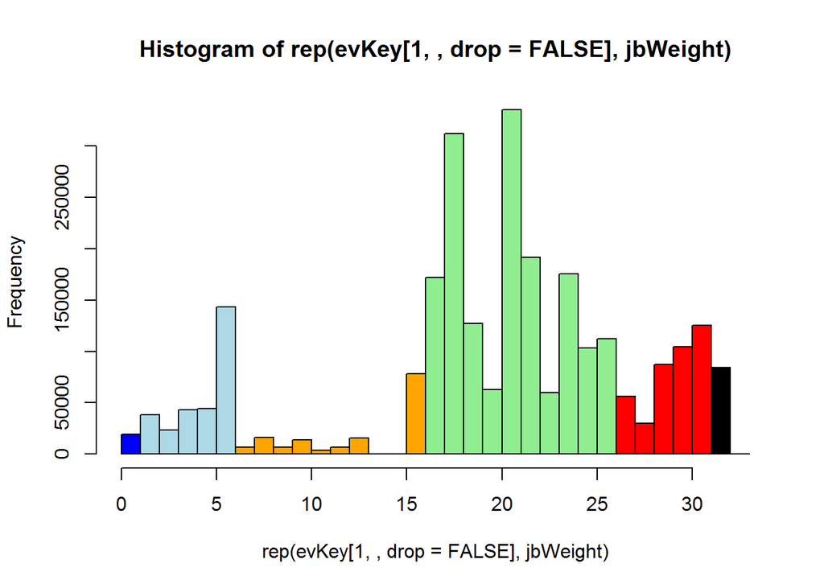

```r
# Best draws (keep all is on left)
hist(rep(evKey[1, , drop=FALSE], jbWeight),
     breaks=0:33,
     col=c( rep("blue", 1), rep("lightblue", 5), rep("orange", 10),
            rep("lightgreen", 10), rep("red", 5), rep("black", 1)
           )
     )
```

```r
# By type of draw (keep all is on left, value 1)
newCutIdx <- cut(rep(evKey[1, ,drop=FALSE], jbWeight),
                 breaks=c(0.5, 1.5, 6.5, 16.5, 26.5, 31.5, 32.5)
                 )
data.frame(newType=newCutIdx) %>%
    group_by(newType) %>% summarize(ct=n())
```

```
## Source: local data frame [6 x 2]
##
##       newType      ct
##        (fctr)   (int)
## 1   (0.5,1.5]   19488
## 2   (1.5,6.5]  292176
## 3  (6.5,16.5]  147528
## 4 (16.5,26.5] 1651440
## 5 (26.5,31.5]  403968
## 6 (31.5,32.5]   84360
```

```r
proc.time() - startTime
```

```
##    user  system elapsed
##    1.00    0.05    1.06
```

Good news, the overall game EV matches the theoretical 99.54%, while the counts of holds by number of cards also matches to the theory.

Further, histograms and EV are examined by starting hand type being RF/SF/Quad/FH:

```r
startTime <- proc.time()


# Overall Game EV - dealt RF/SF/Quads/FH
summary(rep(evKey[2, , drop=FALSE][evSmall0 %in% c(8, 24, 49, 799)],
            jbWeight[evSmall0 %in% c(8, 24, 49, 799)]
            )
        )
```

```
##    Min. 1st Qu.  Median    Mean 3rd Qu.    Max.
##    8.00    8.00    8.00   11.32    8.00  799.00
```

```r
1 + mean(rep(evKey[2, , drop=FALSE][evSmall0 %in% c(8, 24, 49, 799)],
            jbWeight[evSmall0 %in% c(8, 24, 49, 799)]
            )
        )
```

```
## [1] 12.3176
```

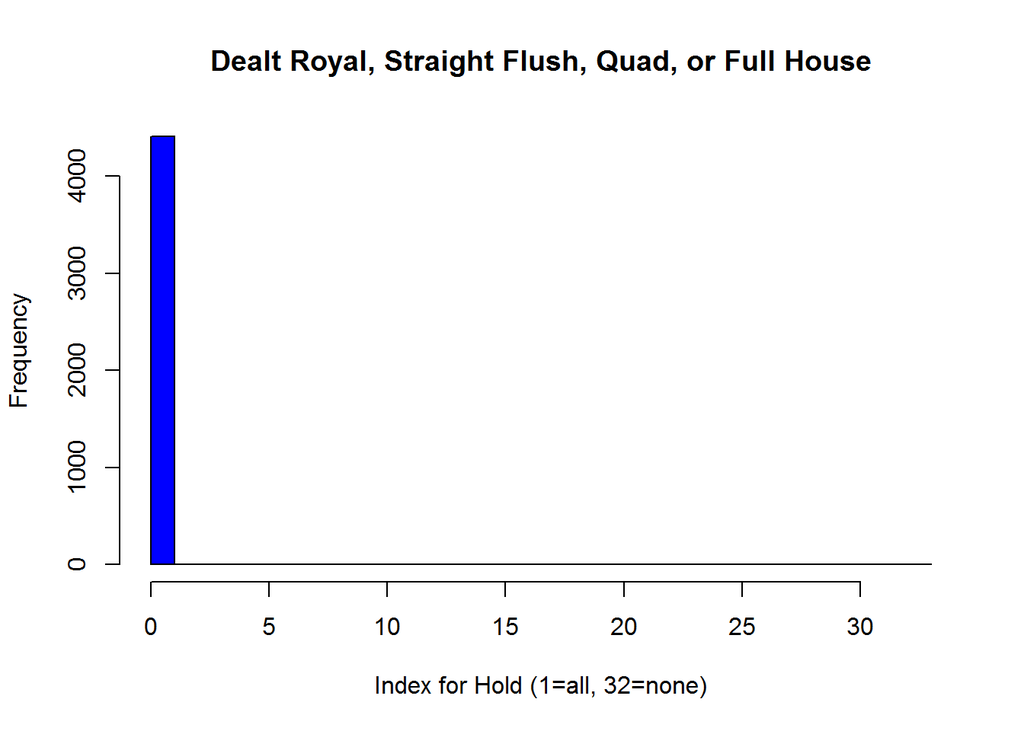

```r
# Best draws (keep all is on left)
hist(rep(evKey[1, , drop=FALSE][evSmall0 %in% c(8, 24, 49, 799)],
         jbWeight[evSmall0 %in% c(8, 24, 49, 799)]
         ),
     breaks=0:33,
     col=c( rep("blue", 1), rep("lightblue", 5), rep("orange", 10),
            rep("lightgreen", 10), rep("red", 5), rep("black", 1)
           ),
     main="Dealt Royal, Straight Flush, Quad, or Full House",
     xlab="Index for Hold (1=all, 32=none)"
     )
```

```r
data.frame(idx=rep(evKey[1, , drop=FALSE][evSmall0 %in% c(8, 24, 49, 799)],
                   jbWeight[evSmall0 %in% c(8, 24, 49, 799)]
                   )
           ) %>% group_by(idx) %>% summarize(ct=n())
```

```
## Source: local data frame [1 x 2]
##
##     idx    ct
##   (dbl) (int)
## 1     1  4408
```

```r
proc.time() - startTime
```

```
##    user  system elapsed
##    0.06    0.00    0.06
```

Further, histograms and EV are examined by starting hand type being Flush/Straight:

```r
startTime <- proc.time()


# Overall Game EV - dealt Flush/Straight
summary(rep(evKey[2, , drop=FALSE][evSmall0 %in% c(3, 5)],
            jbWeight[evSmall0 %in% c(3, 5)]
            )
        )
```

```
##    Min. 1st Qu.  Median    Mean 3rd Qu.    Max.
##   3.000   3.000   3.000   3.865   5.000  18.600
```

```r
1 + mean(rep(evKey[2, , drop=FALSE][evSmall0 %in% c(3, 5)],
            jbWeight[evSmall0 %in% c(3, 5)]
            )
        )
```

```
## [1] 4.865319
```

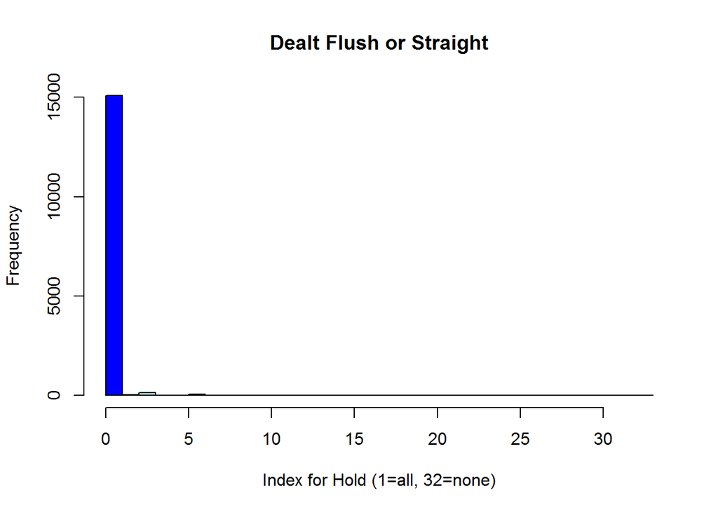

```r
# Best draws (keep all is on left)
hist(rep(evKey[1, , drop=FALSE][evSmall0 %in% c(3, 5)],
         jbWeight[evSmall0 %in% c(3, 5)]
         ),
     breaks=0:33,
     col=c( rep("blue", 1), rep("lightblue", 5), rep("orange", 10),
            rep("lightgreen", 10), rep("red", 5), rep("black", 1)
           ),
     main="Dealt Flush or Straight",
     xlab="Index for Hold (1=all, 32=none)"
     )
```

```r
data.frame(idx=rep(evKey[1, , drop=FALSE][evSmall0 %in% c(3, 5)],
                   jbWeight[evSmall0 %in% c(3, 5)]
                   )
           ) %>% group_by(idx) %>% summarize(ct=n())
```

```
## Source: local data frame [4 x 2]
##
##     idx    ct
##   (dbl) (int)
## 1     1 15080
## 2     2    28
## 3     3   128
## 4     6    72
```

```r
proc.time() - startTime
```

```
##    user  system elapsed
##    0.06    0.02    0.08
```

So, while you always keep the dealt Royal, Straight Flush, Quads, and Full House, there are a handful of occasions where you pitch one card from the dealt straight or dealt flush to chase a better hand.

Further, histograms and EV are examined by starting hand type being Trips/Two Pair:

```r
startTime <- proc.time()


# Overall Game EV - dealt Trips/Two Pair
summary(rep(evKey[2, , drop=FALSE][evSmall0 %in% c(1, 2)],
            jbWeight[evSmall0 %in% c(1, 2)]
            )
        )
```

```
##    Min. 1st Qu.  Median    Mean 3rd Qu.    Max.
##   1.596   1.596   1.596   2.121   3.302   3.302
```

```r
1 + mean(rep(evKey[2, , drop=FALSE][evSmall0 %in% c(1, 2)],
            jbWeight[evSmall0 %in% c(1, 2)]
            )
        )
```

```
## [1] 3.120899
```

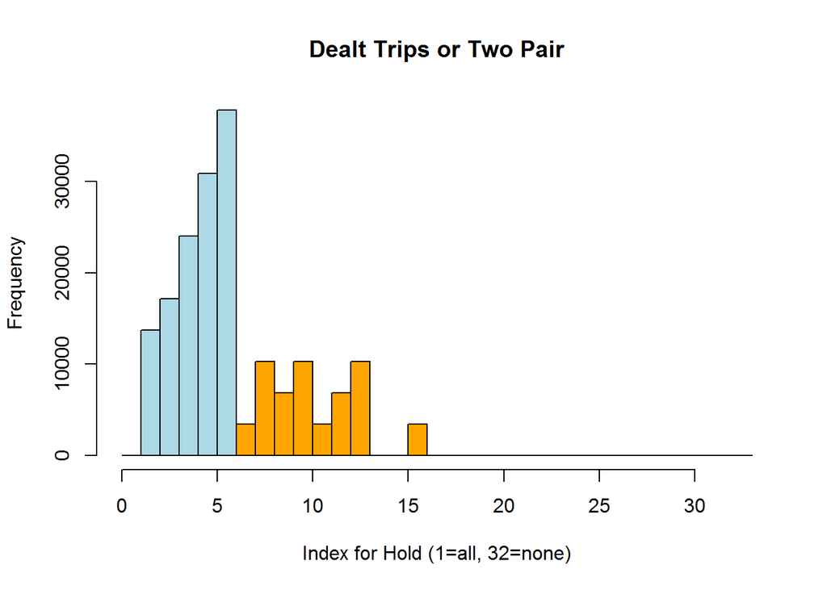

```r
# Best draws (keep all is on left)
hist(rep(evKey[1, , drop=FALSE][evSmall0 %in% c(1, 2)],
         jbWeight[evSmall0 %in% c(1, 2)]
         ),
     breaks=0:33,
     col=c( rep("blue", 1), rep("lightblue", 5), rep("orange", 10),
            rep("lightgreen", 10), rep("red", 5), rep("black", 1)
           ),
     main="Dealt Trips or Two Pair",
     xlab="Index for Hold (1=all, 32=none)"
     )
```

```r
data.frame(idx=rep(evKey[1, , drop=FALSE][evSmall0 %in% c(1, 2)],
                   jbWeight[evSmall0 %in% c(1, 2)]
                   ),
           typ=rep(evSmall0[evSmall0 %in% c(1, 2)],
                   jbWeight[evSmall0 %in% c(1, 2)]
                   )
           ) %>% group_by(typ, idx) %>% summarize(ct=n())
```

```
## Source: local data frame [13 x 3]
## Groups: typ [?]
##
##      typ   idx    ct
##    (dbl) (dbl) (int)
## 1      1     2 13728
## 2      1     3 17160
## 3      1     4 24024
## 4      1     5 30888
## 5      1     6 37752
## 6      2     7  3432
## 7      2     8 10296
## 8      2     9  6864
## 9      2    10 10296
## 10     2    11  3432
## 11     2    12  6864
## 12     2    13 10296
## 13     2    16  3432
```

```r
proc.time() - startTime
```

```
##    user  system elapsed
##    0.10    0.02    0.11
```

So, you always keep dealt Trips (draw 2) and always keep a dealt Two Pair (draw 1).

Further, histograms and EV are examined by starting hand type being a Paying Pair:

```r
startTime <- proc.time()


# Overall Game EV - dealt Paying Pair
summary(rep(evKey[2, , drop=FALSE][evSmall0 %in% c(0)],
            jbWeight[evSmall0 %in% c(0)]
            )
        )
```

```
##    Min. 1st Qu.  Median    Mean 3rd Qu.    Max.
##  0.5365  0.5365  0.5365  0.5471  0.5365 18.6600
```

```r
1 + mean(rep(evKey[2, , drop=FALSE][evSmall0 %in% c(0)],
            jbWeight[evSmall0 %in% c(0)]
            )
        )
```

```
## [1] 1.547121
```

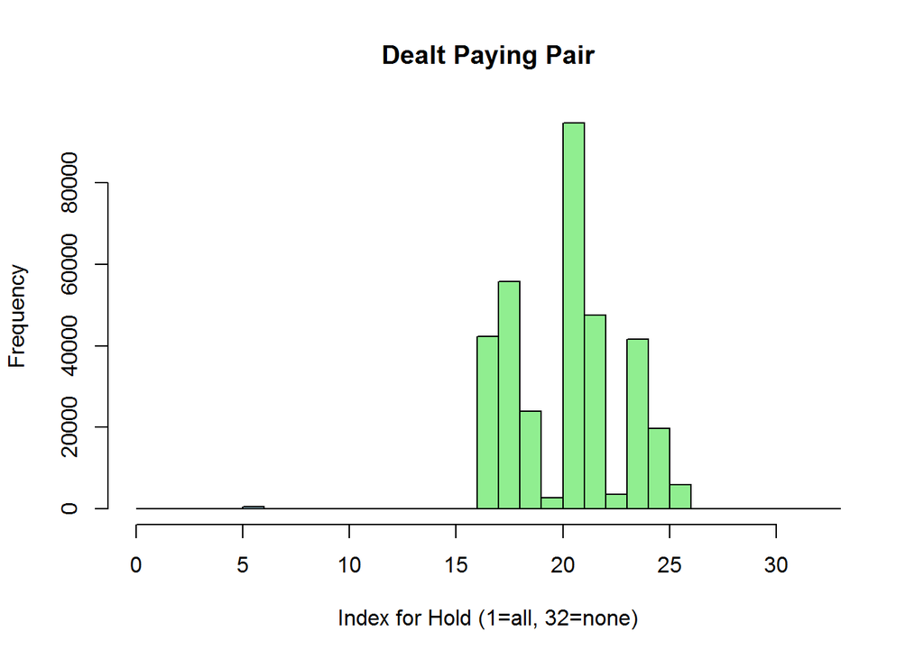

```r
# Best draws (keep all is on left)
hist(rep(evKey[1, , drop=FALSE][evSmall0 %in% c(0)],
         jbWeight[evSmall0 %in% c(0)]
         ),
     breaks=0:33,
     col=c( rep("blue", 1), rep("lightblue", 5), rep("orange", 10),
            rep("lightgreen", 10), rep("red", 5), rep("black", 1)
           ),
     main="Dealt Paying Pair",
     xlab="Index for Hold (1=all, 32=none)"
     )
```

```r
data.frame(idx=rep(evKey[1, , drop=FALSE][evSmall0 %in% c(0)],
                   jbWeight[evSmall0 %in% c(0)]
                   ),
           typ=rep(evSmall0[evSmall0 %in% c(0)],
                   jbWeight[evSmall0 %in% c(0)]
                   )
           ) %>% group_by(typ, idx) %>% summarize(ct=n())
```

```
## Source: local data frame [11 x 3]
## Groups: typ [?]
##
##      typ   idx    ct
##    (dbl) (dbl) (int)
## 1      0     6   456
## 2      0    17 42240
## 3      0    18 55680
## 4      0    19 24000
## 5      0    20  2664
## 6      0    21 94560
## 7      0    22 47520
## 8      0    23  3564
## 9      0    24 41580
## 10     0    25 19788
## 11     0    26  5868
```

```r
proc.time() - startTime
```

```
##    user  system elapsed
##    0.14    0.00    0.14
```

Lastly, histograms and EV are examined by starting hand type being Nothing, with distinction for whether the nother includes a low pair:

```r
startTime <- proc.time()


# Overall Game EV - dealt Nothing
summary(rep(evKey[2, , drop=FALSE][evSmall0 %in% c(-1)],
            jbWeight[evSmall0 %in% c(-1)]
            )
        )
```

```
##    Min. 1st Qu.  Median    Mean 3rd Qu.    Max.
## -0.6426 -0.5217 -0.4210 -0.3317 -0.1763 18.6800
```

```r
1 + mean(rep(evKey[2, , drop=FALSE][evSmall0 %in% c(-1)],
            jbWeight[evSmall0 %in% c(-1)]
            )
        )
```

```
## [1] 0.6682764
```

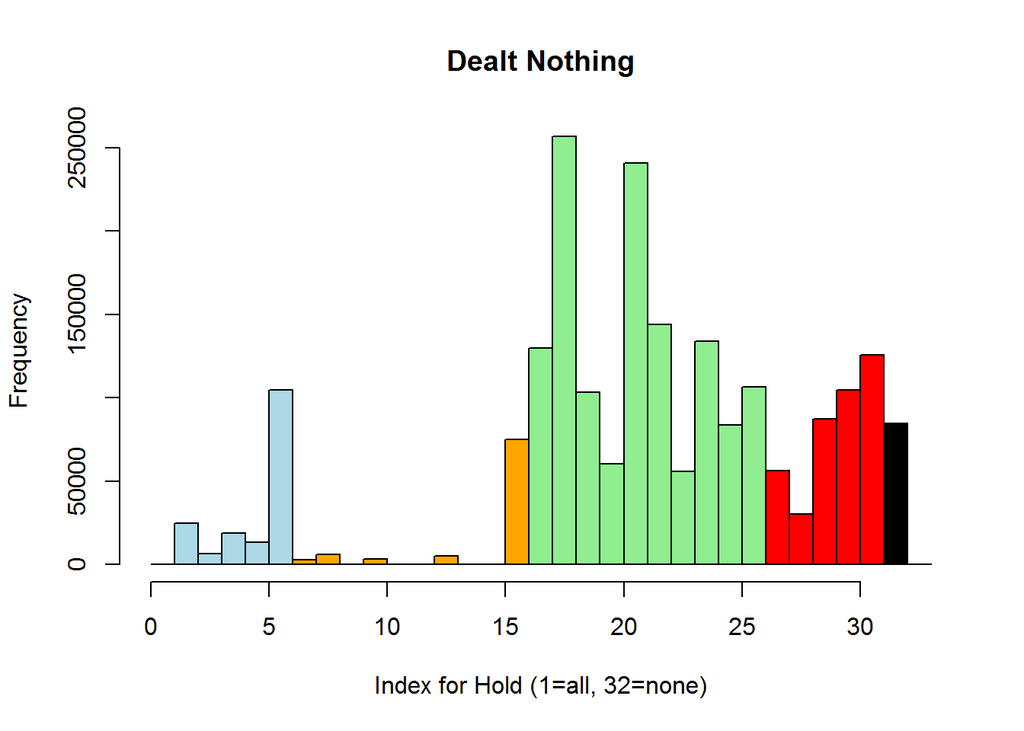

```r
# Best draws (keep all is on left)
hist(rep(evKey[1, , drop=FALSE][evSmall0 %in% c(-1)],
         jbWeight[evSmall0 %in% c(-1)]
         ),
     breaks=0:33,
     col=c( rep("blue", 1), rep("lightblue", 5), rep("orange", 10),
            rep("lightgreen", 10), rep("red", 5), rep("black", 1)
           ),
     main="Dealt Nothing",
     xlab="Index for Hold (1=all, 32=none)"
     )
```

```r
data.frame(idx=rep(evKey[1, , drop=FALSE][evSmall0 %in% c(-1)],
                   jbWeight[evSmall0 %in% c(-1)]
                   ),
           typ=rep(evSmall0[evSmall0 %in% c(-1)],
                   jbWeight[evSmall0 %in% c(-1)]
                   )
           ) %>% group_by(typ, idx) %>% summarize(ct=n())
```

```
## Source: local data frame [26 x 3]
## Groups: typ [?]
##
##      typ   idx     ct
##    (dbl) (dbl)  (int)
## 1     -1     2  24780
## 2     -1     3   6276
## 3     -1     4  18804
## 4     -1     5  13356
## 5     -1     6 104724
## 6     -1     7   3000
## 7     -1     8   6048
## 8     -1    10   3480
## 9     -1    13   5184
## 10    -1    16  74904
## ..   ...   ...    ...
```

```r
# Check for 1) small pairs, and 2) 4-flushes
temp <- jbSmall[evSmall0 %in% c(-1), ]
tempLowPair <- apply(temp %% 13, 1, FUN=function(x) { length(x) != length(unique(x)) } )
tempFourFlush <- apply((temp-1) %/% 13, 1,
                       FUN=function(x) { max(sum(x == 0), sum(x == 1), sum(x == 2), sum(x == 3)) == 4 }
                       )
tempCutIdx <- cut(evKey[1, , drop=FALSE][evSmall0 %in% c(-1)],
                  breaks=c(0.5, 1.5, 6.5, 16.5, 26.5, 31.5, 32.5)
                  )

data.frame(isLow=tempLowPair, isFour=tempFourFlush,
           idxCut=tempCutIdx, wgt=jbWeight[evSmall0 %in% c(-1)]
           ) %>% group_by(isLow, isFour, idxCut) %>% summarize(ct=sum(wgt))
```

```
## Source: local data frame [12 x 4]
## Groups: isLow, isFour [?]
##
##    isLow isFour      idxCut     ct
##    (lgl)  (lgl)      (fctr)  (dbl)
## 1  FALSE  FALSE   (1.5,6.5]  75972
## 2  FALSE  FALSE  (6.5,16.5]  80784
## 3  FALSE  FALSE (16.5,26.5] 580836
## 4  FALSE  FALSE (26.5,31.5] 403968
## 5  FALSE  FALSE (31.5,32.5]  84360
## 6  FALSE   TRUE   (1.5,6.5]  69096
## 7  FALSE   TRUE  (6.5,16.5]   7524
## 8   TRUE  FALSE   (1.5,6.5]    252
## 9   TRUE  FALSE  (6.5,16.5]   3168
## 10  TRUE  FALSE (16.5,26.5] 733140
## 11  TRUE   TRUE   (1.5,6.5]  22620
## 12  TRUE   TRUE  (6.5,16.5]   1140
```

```r
proc.time() - startTime
```

```
##    user  system elapsed
##    2.00    0.09    2.09
```

The following patterns are noted:

- When there is no low pair and no four-flush, the optimal hold can be anything from 0-4 cards
- When there is a four flush, regardless of whether there is a low pair, the optimal hold is either 3 cards (3 RF draw) or 4 cards (4 FL draw)
- When there is a low pair but no four-flush, the optimal hold can be anything from 2 cards (large majority) to 3 cards (specifically 3 RF) or 4 cards (specifically KQJT)

## Timing Conisderations

Interestingly, a large chunk of this can seemingly be run once and cached, keeping track of the following hands:

- Royal Flush
- Straight Flush
- AAAA with 2-4
- AAAA with J-K
- AAAA with 5-T
- 2222/3333/4444 with A
- 2222/3333/4444 with 2-4
- 2222/3333/4444 with J-K
- 2222/3333/4444 with 5-T
- JJJJ/QQQQ/KKKK with A
- JJJJ/QQQQ/KKKK with 2-4
- JJJJ/QQQQ/KKKK with J-K
- JJJJ/QQQQ/KKKK with 5-T
- 5555-TTTT
- Full House
- Flush
- Straight
- Trips
- Two Pair
- Pair AA
- Pair KK
- Pair QQ
- Pair JJ
- Pair TT
- Pair 22-99

Primarily, the distinction is to more precisely track the quad type/kicker and the pair type, allowing for games with bonus quads, Kings or Better, and the like. Wild cards will not be used, nor will anything that depends on the suits or sequencing of the cards (i.e., KQJTA and AKQJT and TJQKA are all considered the same outcome; a royal flush in spades is considered the same as a royal flush in clubs; etc.).